# CSDA1040 Assignment 3 Time Series Analysis

Group D: Amitabh Kumar, Joseph Gyamfi, (Jamie) Yeon Ju Heo, and Rob Ness

July 28, 2019

# Abstract

## Our project focuses on how to reduce investment risk by predicting the future value of varied stock indices using time series analysis. We performed both a univariate and multivariate time series analysis, followed by a clustering analysis to segment the various indices into groupings to help guide investors when diversifying their investment portfolios. Our results indicated that the NaÃ¯ve models performed better than ARIMA and Exponential Smoothing when forecasting the S&P500’s performance. We also determined that in a three-cluster solution, both the S&P500 and NASDAQ were in one cluster, and NYSE and then Heng Seng were in separate clusters themselves.

# Introduction and Method

## Time series analysis comprises methods for analyzing time series data in order to extract meaningful statistics and other characteristics of the data.

## Time series forecasting is the use of a model to predict future values based on previously observed values.

## Time series analysis can be used in a multitude of business applications for forecasting a quantity into the future and explaining its historical patterns. Here are just a few examples of possible use cases:

### . Explaining seasonal patterns in sales

### . Predicting the expected number of incoming or churning customers

### . Estimating the effect of a newly launched product on number of sold units

### . Detecting unusual events and estimating the magnitude of their effect

## Using time series analysis, our project focuses on how to reduce investment risk by predicting the future value of multiple stock market indices. Within that construct, we further clustered four major indices namely, Standard & Poor’s 500 (S&P500), The New York Stock Exchange (NYSE), NASDAQ, and Hang Seng Indexes (HSI). S&P500 focuses on industrial stocks, NYSE specialises in financial instruments, NASDAQ features technology stocks, while the HSI has a varied portfolio of market segments including real estate, energy, technology, and financial, among others. Understanding this clustering of the indices will help an investor consider multiple options and diversify their portfolio.

## As part of this project, we preformed the following tasks:

### . Detailed univariate time series analysis of the S&P500;

### . A multivariate time series analysis of S&P500 and selected macro-economic indicators (oil prices, CPI, GDP, and the housing index);

### . Clustering of the four major indices as mentioned above;

### . Developed an R Shiny app based on a univariate time series analysis.

## While our Shiny app - as a proof-of-concept - focuses on a univariate series, our R markdown code development showcases our ability to develop a forecasting system using R, and present a multivariate data set as applied against several forecast evaluation methods including; ARIMA, Exponential Smoothing, Naïve Forecasting, and Seasonal Naïve Forecasting.

## Our Method for Univariate Analysis

### . Data Exploration: Visualized data set and computed summary statistics to understand our data;

### . Data Decomposition: Identified data, residuals, seasonal component, and trend;

### . Initial Test for Stationarity: Conducted Ljung-Box Test, and Dickey-Fuller Test;

### . Determined the ARIMA model parameters using both Auto-Correlation Function (ACF) and Partial Auto-Correlation Function (PACF) plots;

### . Performed transformation using differencing (diff() method) to adjust for non-stationarity;

### . Re-tested for stationarity to ensure that the data set was indeed stationary;

### . Completed residual diagnostics to ensure that the residuals are White noise;

### . Split the dataset into training and testing data;

### . We built the four aforementioned models, applied them to the entire dataset to forecast 12-months worth of data.

## Our Method for Multivariate Analysis

### Following the previously-defined Univariate method, we expanded our analysis to accommodate the multivariate nature of our data.

### . To test for stationarity, we used the Johansen Test;

### . We determined the optimal lag length using the VARselects function;

### . Split the dataset into training and testing data;

### . We built the four aforementioned models, applied them to our data sets to forecast 12-months worth of data.

## Clustering

### Our initial data included S&P 500, NYSE, and NASDAQ. We then elected to diversify our basket to include HSI and provide a different perspective of global market activity instead of only regional (North America).

### . We employed hierarchical clustering using both Dynamic Time Warping (DTW), and Euclidean Distance measures;

### . We also performed K-means clustering.

# Dataset Description

```r
#source(here("src",'helper_functions.R'))
# Helper Function Script

#RUN THESE COMMANDS IF THESE THIRD PARTY PACKAGES HAVE NOT BEEN DOWNLOADED YET

# install.packages("ggplot2")
# install.packages("forecast")
# install.packages("plotly")
# install.packages("ggfortify")
# install.packages("tseries")
# install.packages("gridExtra")
# install.packages("docstring")
# install.packages("here")

library(ggplot2)
library(forecast)
library(plotly)
library(ggfortify)
library(tseries)
library(gridExtra)
library(docstring)
library(readr)
library(here)
# NOTE: For more information on helper functions use ?function_name
# LOAD DATA
data_master <- read.csv("data_master_1.csv")

data_master$year <- NULL
data_master$month <- NULL
data_master$year <- NULL
data_master$trillion <- NULL
data_master$billion <- NULL

create_ts <- function(x){
  ts(x, start = c(1995, 1), frequency = 12)
}

data_master <- lapply(data_master, create_ts)

# Contains functions that create ggplot2 plots of integral time series plots
# use ?function_name for more details.

plot_time_series <- function(ts_object, ts_object_name){
  #' Plot Time Series Object
  #'
  #' Creates time series plot utilizing \code{ggplot2} utlizing
  #' custom themes to ensure plots are
  #' consistent. Utlizes \code{autoplot} function for plots.
  #'
  #' @param ts_object time series object used to create plot
  #' @param ts_object_name preferred title of plot
  #' @examples
  #' data(AirPassengers)
  #'
  #' air_pass_ts <- as.ts(AirPassengers)
  #'
  #' plot_time_series(air_pass_ts, 'Air Passengers')
  if (is.ts(ts_object) == TRUE){
    if(missing(ts_object_name)) {
      warning('Title for plot not entered!')
    } else {
      startYear <- start(ts_object) # Grabs start date
      endYear <- end(ts_object) # Grabs end date
      tsPlot <- autoplot(ts_object,
                         ts.colour = 'turquoise4',
                         size = 1,
                         main = sprintf("Plot of %s Time Series (%s - %s)",
                                        ts_object_name, startYear[1], endYear[1])) +
        theme(axis.text.x = element_text(angle = 35, hjust = 1),
              panel.background = element_rect(fill = "gray98"),
              axis.line.x = element_line(colour="gray"),
              axis.line.y = element_line(colour="gray")) +
        labs(x = "Year", y = "Closing Values")
      return(tsPlot)
    }
  }
  else {
    warning('Make sure object entered is time-series object!')
  }
}

# FUNCTION FOR ACF AND PACF PLOTS
plot_acf_pacf <- function(ts_object, ts_object_name){
  #' Plot ACF and PACF for Time Series Object
  #'
  #' Creates \emph{Autocorrelation} and \emph{Partial Autocorrelation} plot
  #' utilizing \code{ggplot2} with custom themes to ensure plots are
  #' consistent. Utlizes \code{autoplot} function for plots.
  #'
  #' @param ts_object time series object used to create plot
  #' @param ts_object_name preferred title of plot
  #' @examples
  #' data(AirPassengers)
  #'
  #' air_pass_ts <- as.ts(AirPassengers)
  #'
  #' plot_acf_pacf(air_pass_ts, 'Air Passengers Data Set')
  if (is.ts(ts_object) == TRUE){
    if(missing(ts_object_name)) {
      warning('Title for plot not entered!')
    } else {
      a <- autoplot(acf(ts_object, plot = FALSE),
                    colour = 'turquoise4',
                    conf.int.fill = '#4C4CFF',
                    conf.int.value = 0.95, conf.int.type = 'ma') +
        theme(panel.background = element_rect(fill = "gray98"),
              axis.line.y   = element_line(colour="gray"),
              axis.line.x = element_line(colour="gray")) +
        ggtitle(sprintf("ACF plot of %s", ts_object_name))

      b <- autoplot(pacf(ts_object, plot = FALSE),
                    colour = 'turquoise4',
                    conf.int.fill = '#4C4CFF',
                    conf.int.value = 0.95, conf.int.type = 'ma') +
        theme(panel.background = element_rect(fill = "gray98"),
              axis.line.y   = element_line(colour="gray"),
              axis.line.x = element_line(colour="gray")) + labs(y="PACF") +
        ggtitle(sprintf("PACF plot of %s", ts_object_name))

      grid.arrange(a, b)
    }
  } else {
    warning('Make sure object entered is time-series object!')
  }
}

# Decomposed Plot
plot_decomp <- function(ts_object, ts_object_name){
  #' Plots Seasonal Decomposition for Time Series Object
  #'
  #' Decomposes time series object to \emph{Seasonal},
  #' \emph{Remainder}, and \emph{Trend}.
  #' Utilizing \code{ggplot2} with custom themes to ensure plots are
  #' consistent. Utlizes \code{autoplot} function for plots.
  #'
  #' @param ts_object time series object used to create plot
  #' @param ts_object_name preferred title of plot
  #' @examples
  #' data(AirPassengers)
  #'
  #' air_pass_ts <- as.ts(AirPassengers)
  #'
  #' plot_decomp(air_pass_ts, 'Air Passengers Data Set')
  if (is.ts(ts_object) == TRUE){
    autoplot(stl(ts_object, s.window = "periodic"),
             main = sprintf("Decomposition Plot of %s", ts_object_name),
             ts.colour = "turquoise4") +
      theme(panel.background = element_rect(fill = "gray98"),
            axis.line.y   = element_line(colour="gray"),
            axis.line.x = element_line(colour="gray"))
  } else {
    warning('Make sure object entered is time-series object!')
  }
}

# Seasonal Plot
plot_seasonal <- function(ts_object, ts_object_name){

  #' Plots Seasonal Component for Time Series Object
  #'
  #' Plots \emph{Seasonal} aspect of time series object.
  #' Utilizing \code{ggplot2} with custom themes to ensure plots are
  #' consistent. Utlizes \code{autoplot} function for plots.
  #'
  #' @param ts_object time series object used to create plot
  #' @param ts_object_name preferred title of plot
  #' @examples
  #' data(AirPassengers)
  #'
  #' air_pass_ts <- as.ts(AirPassengers)
  #'
  #' plot_seasonal(air_pass_ts, 'Air Passengers Data Set')
  if (is.ts(ts_object) == TRUE){
    ggseasonplot(ts_object, xlab="Year",
                 main=sprintf("Seasonal Plot of %s", ts_object_name),
                 year.labels=TRUE, year.labels.left=TRUE,
                 col=1:20, pch=19) +
      theme(panel.background = element_rect(fill = "gray98"),
            axis.line.y = element_line(colour="gray"),
            axis.line.x = element_line(colour="gray"))
  } else {
    warning('Make sure object entered is time-series object!')
  }
}

ggtsdiag_custom <- function(object, ts_object_name, gof.lag = 10,
                            conf.int = TRUE,
                            conf.int.colour = '#0000FF', conf.int.linetype = 'dashed',
                            conf.int.fill = NULL, conf.int.alpha = 0.3,
                            ad.colour = '#888888', ad.linetype = 'dashed', ad.size = .2,
                            nrow = NULL, ncol = 1, ...) {
  rs <- stats::residuals(object)
  if (is.null(rs)) {
    rs <- object$residuals
  }
  if (is.null(rs)) {
    rs <- object$resid
  }

  p.std <- ggplot2::autoplot(rs, na.action = stats::na.pass,
                             ts.colour = 'turquoise4', size = 1.05) +
    ggplot2::geom_hline(yintercept = 0,
                        linetype = ad.linetype, size = ad.size,
                        colour = ad.colour) +
    labs(subtitle = '') +
    ggplot2::ggtitle(sprintf("Residual Diagnostics for %s \nNon-Standardized Residuals",
                             ts_object_name))

  acfobj <- stats::acf(rs, plot = FALSE, na.action = stats::na.pass)
  p.acf <- autoplot(acfobj, conf.int = conf.int,
                    conf.int.colour = conf.int.colour,
                    conf.int.linetype = conf.int.linetype,
                    conf.int.fill = conf.int.fill,
                    conf.int.alpha = conf.int.alpha,
                    colour = 'turquoise4', size = 1.25)
  p.acf <- p.acf + ggplot2::ggtitle('ACF of Residuals')

  nlag <- gof.lag
  pval <- numeric(nlag)
  for (i in 1L:nlag) pval[i] <- stats::Box.test(rs, i, type = "Ljung-Box")$p.value
  lb.df <- data.frame(Lag = 1L:nlag, `p value` = pval,
                      lower = -0.05, upper = 0.05)
  # Unnable to create column with space by above expression
  colnames(lb.df) <- c('Lag', 'p value', 'lower', 'upper')
  p.lb <- ggplot2::ggplot(data = lb.df, mapping = ggplot2::aes_string(x = 'Lag')) +
    ggplot2::geom_point(mapping = ggplot2::aes_string(y = '`p value`'), na.rm = TRUE,
                        colour = 'turquoise4') +
    ggplot2::scale_y_continuous(limits=c(-0.1, 1)) +
    ggplot2::ggtitle('p values for Ljung-Box statistic')

  p.lb <- ggfortify:::plot_confint(p = p.lb, data = lb.df, conf.int = conf.int,
                                   conf.int.colour = conf.int.colour,
                                   conf.int.linetype = conf.int.linetype,
                                   conf.int.fill = conf.int.fill, conf.int.alpha = conf.int.alpha)

  if (is.null(ncol)) { ncol <- 0 }
  if (is.null(nrow)) { nrow <- 0 }
  new('ggmultiplot', plots = list(p.std, p.acf, p.lb), nrow = nrow, ncol = ncol)
}


###########################################################################################
# HERE FOUND AT http://librestats.com/2012/06/11/autoplot-graphical-methods-with-ggplot2/ #
# BY DREW SCHMIDT WITH SLIGHT MODIFICATIONS TO FIT OUR PLOTS                              #
###########################################################################################


autoplot.forecast <- function(forecast, forc_name, ts_object_name,
                              ..., holdout=NaN){
  #' Plots Forecasted values for Time Series Models
  #'
  #' Borrowed from Drew Schmidt, but modified to fit our aesthetic appeal
  #' we create a dataframe with all the appropriate sections (i.e. upper and
  #' lower 95% CI bands, forecasted, actual values, the training time series
  #' object, and upper and lower 80% CI), then we create a \code{ggplot2} object that
  #' reflects the forecasted plot
  #'
  #' @param forecast forecasted values created using \code{forecast} function
  #' @param forc_name name of forecasted method included in title
  #' @param ts_object_name time series name included in title
  #' @param holdout time series object that contains actual values that can be
  #' compared to the forecasted values

  # data wrangling
  time <- attr(forecast$x, "tsp")
  time <- seq(time[1], attr(forecast$mean, "tsp")[2], by=1/time[3])
  lenx <- length(forecast$x)
  lenmn <- length(forecast$mean)

  df <- data.frame(time=time,
                   x=c(forecast$x, forecast$mean),
                   x2=c(forecast$x, rep(NA, lenmn-length(holdout)), holdout),
                   forecast=c(rep(NA, lenx), forecast$mean),
                   low1=c(rep(NA, lenx), forecast$lower[, 1]),
                   upp1=c(rep(NA, lenx), forecast$upper[, 1]),
                   low2=c(rep(NA, lenx), forecast$lower[, 2]),
                   upp2=c(rep(NA, lenx), forecast$upper[, 2]),
                   holdout=c(rep(NA, lenx+lenmn-length(holdout)), holdout)
  )

  ggplot(df, aes(time, x)) +
    geom_ribbon(aes(ymin=low2, ymax=upp2), fill="yellow", na.rm=TRUE) +
    geom_ribbon(aes(ymin=low1, ymax=upp1), fill="orange", na.rm=TRUE) +
    geom_line(data=df, aes(time, x2), color="red")+
    geom_line(colour = "turquoise4", size = 1) +
    geom_line(data=df[!is.na(df$forecast), ], aes(time, forecast), color="blue", na.rm=TRUE) +
    geom_line(data=df[!is.na(df$holdout), ], aes(time, holdout), color="red", na.rm=TRUE) +
    scale_x_continuous(breaks = scales::pretty_breaks(n = 12)) +
    scale_y_continuous("")  +
    theme(axis.text.x = element_text(angle = 35, hjust = 1),
          panel.background = element_rect(fill = "gray98"),
          axis.line.y   = element_line(colour="gray"),
          axis.line.x = element_line(colour="gray")) +
    labs(x = "Year", y = "Closing Values") +
    ggtitle(sprintf('%s Forecast Plot of %s', forc_name, ts_object_name))
}
```

```r
# LOAD YOUR PACKAGES
library(ggplot2)
library(forecast)
library(plotly)
library(ggfortify)
library(tseries)
library(gridExtra)
library(docstring)
library(readr)
library(here)
here() # Should output current work directory
```

```
## [1] "C:/Users/Administrator/Desktop/Data"
```

```r
# Read data
data_master <- read.csv("data_master_1.csv")
attach(data_master)
```

```r
# EXPLORE DATA
str(data_master)
```

```
## 'data.frame':    252 obs. of  22 variables:
##  $ year             : int  1995 1995 1995 1995 1995 1995 1995 1995 1995 1995 ...
##  $ month            : int  1 2 3 4 5 6 7 8 9 10 ...
##  $ m1               : num  1151 1148 1147 1148 1146 ...
##  $ m2               : num  3486 3486 3487 3490 3516 ...
##  $ billion          : int  1000000000 1000000000 1000000000 1000000000 1000000000 1000000000 1000000000 1000000000 1000000000 1000000000 ...
##  $ consumerSentiment: num  97.6 95.1 90.3 92.5 89.8 92.7 94.4 96.2 88.9 90.2 ...
##  $ imports          : int  60745 60076 62272 63448 63474 63617 62700 62289 63088 62462 ...
##  $ inflation        : num  0.4 0.4 0.3 0.3 0.2 0.2 0 0.3 0.2 0.3 ...
##  $ oilPrices        : num  16.6 17.1 17 18.7 18.3 ...
##  $ ppi              : num  123 124 124 125 125 ...
##  $ exports          : int  45619 45914 47483 47032 47646 47425 47377 48555 49976 49332 ...
##  $ cpi              : num  150 151 151 152 152 ...
##  $ unemploymentRate : num  0.073 0.072 0.054 0.058 0.056 0.056 0.057 0.057 0.056 0.055 ...
##  $ fedFunds         : num  0.0553 0.0592 0.0598 0.0605 0.0601 0.06 0.0585 0.0574 0.058 0.0576 ...
##  $ capUtilization   : num  0.849 0.845 0.843 0.84 0.84 0.839 0.833 0.84 0.84 0.836 ...
##  $ sp_500Dividends  : num  0.0283 0.0273 0.0267 0.0261 0.0254 0.0248 0.0241 0.0242 0.0235 0.0234 ...
##  $ nasdaq           : num  755 776 808 829 859 ...
##  $ nyse             : num  2679 2753 2823 2901 2980 ...
##  $ sp_500           : num  465 479 494 508 524 ...
##  $ gdp_us           : num  10.1 10.1 10.1 10.1 10.1 ...
##  $ trillion         : num  1e+12 1e+12 1e+12 1e+12 1e+12 ...
##  $ housingIndex     : num  183 183 183 186 186 ...
```

```r
# sel_vars <- c("year", "oilPrices", "cpi", "nasdaq", "nyse", "sp_500", "gdp_us", "housingIndex")
# data <- data_master[sel_vars]

data_1 <- data_master[c(1,9,12,17:20,22)]
```

```r
str(data_1)
```

```
## 'data.frame':    252 obs. of  8 variables:
##  $ year        : int  1995 1995 1995 1995 1995 1995 1995 1995 1995 1995 ...
##  $ oilPrices   : num  16.6 17.1 17 18.7 18.3 ...
##  $ cpi         : num  150 151 151 152 152 ...
##  $ nasdaq      : num  755 776 808 829 859 ...
##  $ nyse        : num  2679 2753 2823 2901 2980 ...
##  $ sp_500      : num  465 479 494 508 524 ...
##  $ gdp_us      : num  10.1 10.1 10.1 10.1 10.1 ...
##  $ housingIndex: num  183 183 183 186 186 ...
```

```r
# Check for missing values
data_1[!complete.cases(data_1),]
```

```
## [1] year         oilPrices    cpi          nasdaq       nyse
## [6] sp_500       gdp_us       housingIndex
## <0 rows> (or 0-length row.names)
```

```r
# Compute Summary Statistics
summary(data_1[2:8])
```

```
##    oilPrices           cpi            nasdaq            nyse
##  Min.   :  9.80   Min.   :150.3   Min.   : 755.3   Min.   : 2679
##  1st Qu.: 23.64   1st Qu.:171.3   1st Qu.:1702.8   1st Qu.: 5754
##  Median : 46.20   Median :195.0   Median :2210.0   Median : 6846
##  Mean   : 54.60   Mean   :195.9   Mean   :2416.2   Mean   : 7049
##  3rd Qu.: 78.65   3rd Qu.:218.9   3rd Qu.:2791.2   3rd Qu.: 8348
##  Max.   :133.90   Max.   :238.7   Max.   :5072.7   Max.   :11087
##      sp_500           gdp_us       housingIndex
##  Min.   : 464.5   Min.   :10.09   Min.   :182.9
##  1st Qu.:1013.7   1st Qu.:12.53   1st Qu.:231.7
##  Median :1209.8   Median :14.23   Median :311.4
##  Mean   :1224.8   Mean   :13.65   Mean   :291.5
##  3rd Qu.:1400.3   3rd Qu.:14.95   3rd Qu.:343.0
##  Max.   :2099.4   Max.   :16.44   Max.   :378.4
```

```r
# Visualize and correlations and relationships between sp_500 with selected economic indicators

# Scatterplot Matrices from the gclus Package
library(gclus)
dta <- data_1[c(2,3,6,7,8)] # get data
dta.r <- abs(cor(dta)) # get correlations
dta.r
```

```
##              oilPrices       cpi    sp_500    gdp_us housingIndex
## oilPrices    1.0000000 0.8746490 0.5222097 0.8072378    0.6990655
## cpi          0.8746490 1.0000000 0.7153548 0.9695101    0.8443815
## sp_500       0.5222097 0.7153548 1.0000000 0.7714416    0.5980065
## gdp_us       0.8072378 0.9695101 0.7714416 1.0000000    0.9180497
## housingIndex 0.6990655 0.8443815 0.5980065 0.9180497    1.0000000
```

```r
dta.col <- dmat.color(dta.r) # get colors
```

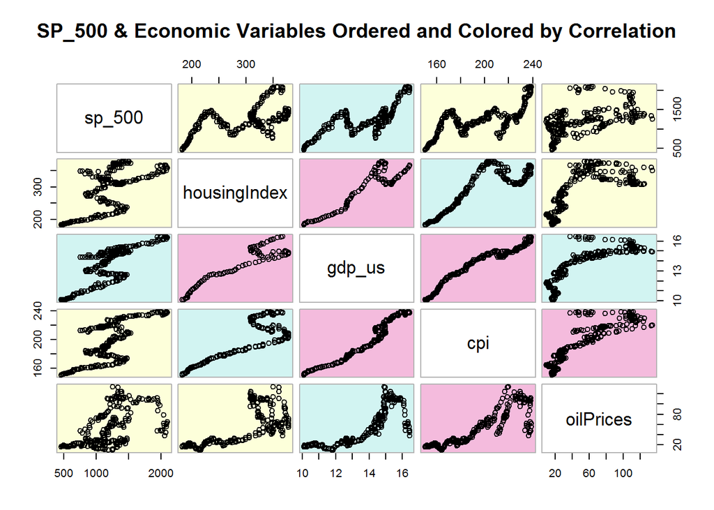

```r
# reorder variables so those with highest correlation are closest to the diagonal
dta.o <- order.single(dta.r)
cpairs(dta, dta.o, panel.colors=dta.col, gap=.5,
       main="SP_500 & Economic Variables Ordered and Colored by Correlation" )
```

```r
# From the correlation numbers and plots, it is clear and reasonably expected that the economic indicators are strongly and highly correlated among themselves than with the sp_500.
```

```r
# Visualize and correlations and relationships among major US stock indices

dta_2 <- data_1[c(4,5,6)] # get data
dta_2.r <- abs(cor(dta_2)) # get correlations
dta_2.r
```

```
##           nasdaq      nyse    sp_500
## nasdaq 1.0000000 0.8393165 0.9490196
## nyse   0.8393165 1.0000000 0.9442761
## sp_500 0.9490196 0.9442761 1.0000000
```

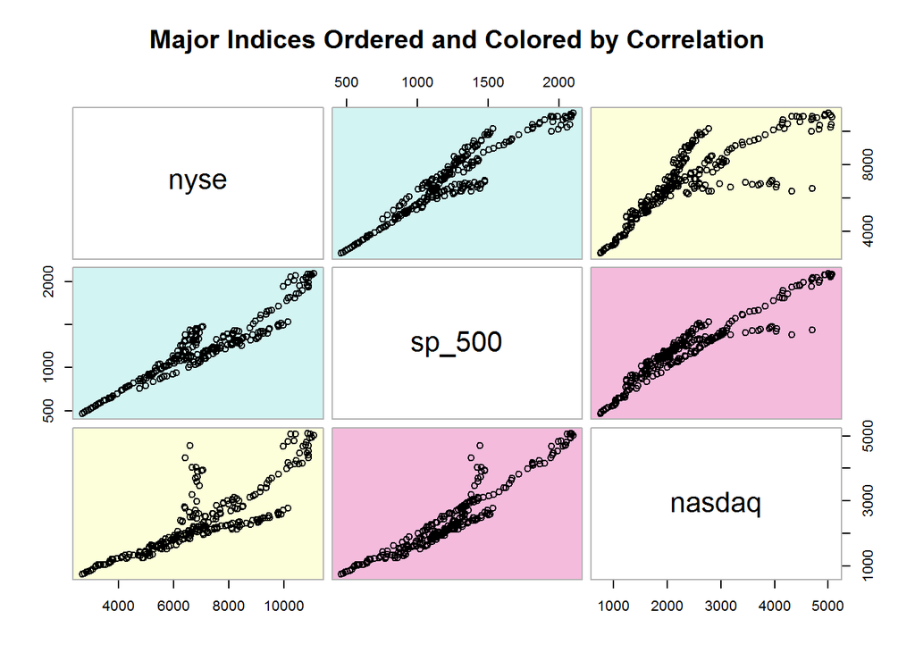

```r
dta_2.col <- dmat.color(dta_2.r) # get colors
# reorder variables so those with highest correlation
# are closest to the diagonal
dta_2.o <- order.single(dta_2.r)
cpairs(dta_2, dta_2.o, panel.colors=dta_2.col, gap=.5,
       main="Major Indices Ordered and Colored by Correlation" )
```

```r
# The major US stock indices are highly correlated, ranging from 0.84 between nasdaq and nyse to 0.95 between nasdaq and sp_500.
```

```r
##################################################################

#Load HANG SENG INDEX data and explore relationship with sp_500

#################################################################
data_hseng <- read.csv("hang_seng_index.csv")
str(data_hseng)
```

```
## 'data.frame':    287 obs. of  4 variables:
##  $ Date     : Factor w/ 287 levels "1/31/1995","1/31/1996",..: 1 96 120 144 168 192 216 240 264 25 ...
##  $ year     : int  1995 1995 1995 1995 1995 1995 1995 1995 1995 1995 ...
##  $ month    : int  1 2 3 4 5 6 7 8 9 10 ...
##  $ Hang_Seng: num  8328 8588 8361 9407 9206 ...
```

```r
data_hseng <- data_hseng[1:nrow(data_master), c(2:4)]

library(dplyr)
data_sp500hseng <- cbind(data_hseng$Hang_Seng, data_master$sp_500)
colnames(data_sp500hseng) <- list("hang_seng", "sp_500")
head(data_sp500hseng)
```

```
##      hang_seng   sp_500
## [1,]    8327.5 464.5475
## [2,]    8587.7 479.0725
## [3,]    8361.0 493.9875
## [4,]    9407.4 507.7250
## [5,]    9206.5 523.6500
## [6,]    9453.4 538.8050
```

```r
colnames(data_sp500hseng)
```

```
## [1] "hang_seng" "sp_500"
```

```r
library(car)
```

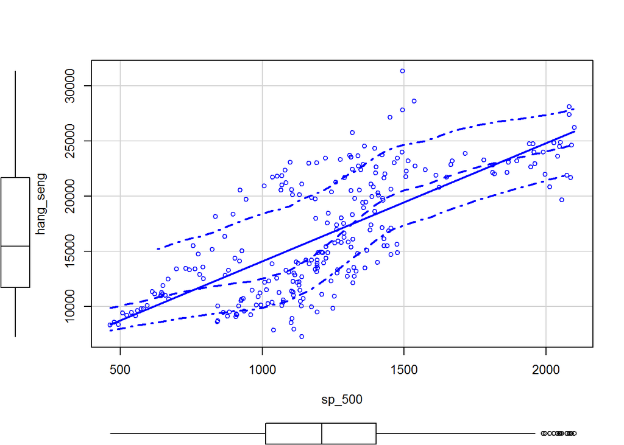

```r
scatterplot(hang_seng ~ sp_500, data=data_sp500hseng)
```

```r
hseng_sp500.corr <- cor(data_sp500hseng) # get correlations
hseng_sp500.corr
```

```
##           hang_seng    sp_500
## hang_seng 1.0000000 0.7202001
## sp_500    0.7202001 1.0000000
```

```r
# The correlation between sp_500 and hang_seng is 0.72 and much less than the minimum correlation among the US stock indices.
```

# For this exercise:

## 1) We will perform a detailed univariate time series analysis of sp_500 and

## 2) Then attempt a multivariate time series analysis of sp_500 and the economic indicators (oilPrices, cpi, gdp_us and housingIndex)

## 3) Lastly, we will peeform clustering on all four indices - sp_500, nasdaq, nyse and hang_seng

# In the future, we will apply the analysis using the underlying stocks or ETFs that make up these indices

# (1) START WITH UNIVARIATE TIME SERIES ANALYSIS

```r
sp_500 <- ts(data_master$sp_500, start=c(1995, 1), freq=12)
```

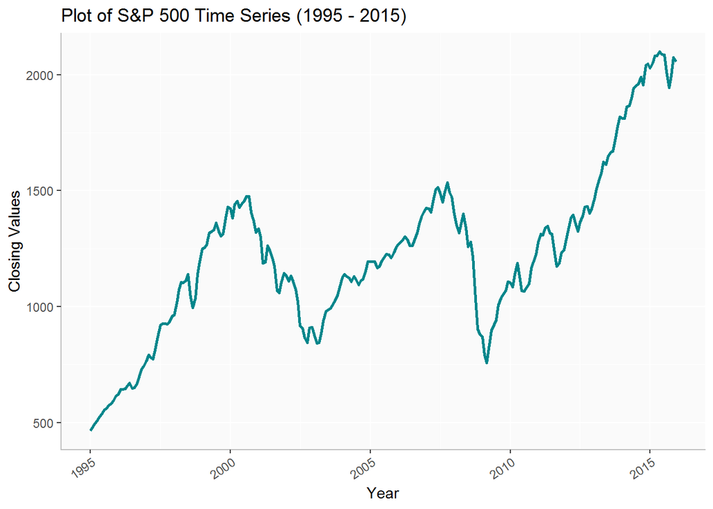

```r
#Here we use our own function called plot_time_series, which does as its name suggests:

# Run helper_functions.R once, to allow you to run most of the functions in this code
plot_time_series(sp_500, 'S&P 500')
```

```r
#Before we begin any analysis, we will be splitting the data to remove 2015 to use as our test set.
sp500_training <- ts(sp_500, start=c(1995, 1), end=c(2014, 12), freq=12)
```

#Plotting our Time Series

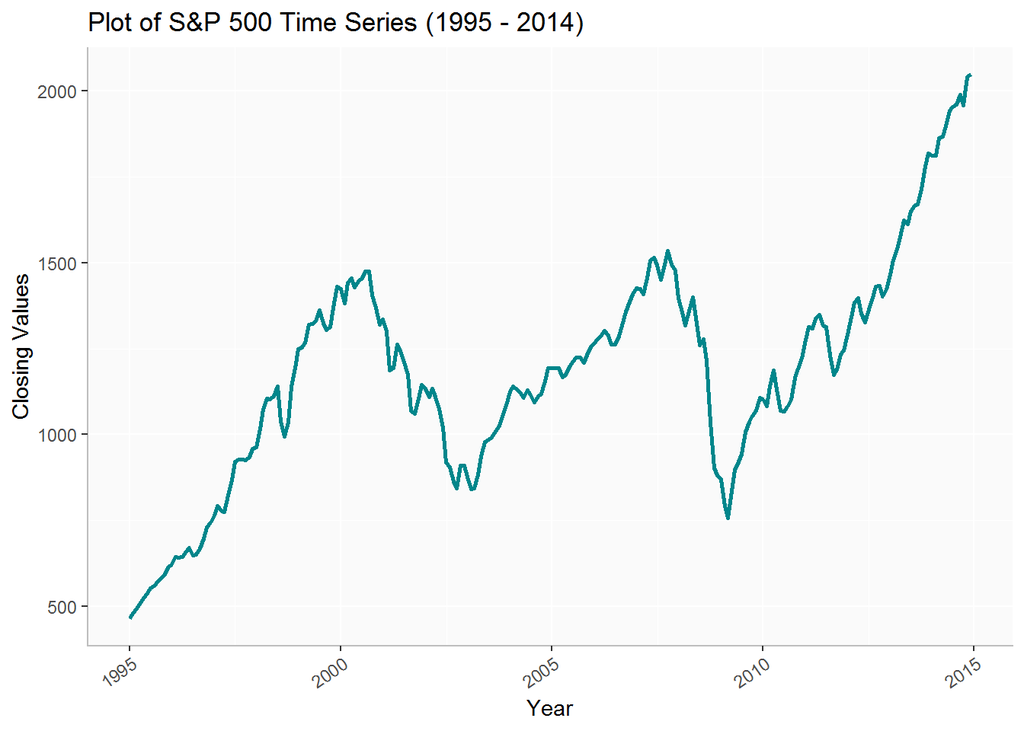

```r
#Plotting the data is arguably the most critical step in the exploratory analysis phase (We chose to emphasize on the time series object that has intervals from 1995 to 2014, which we will explain later!). This enables us to make inferences about important components of the time-series data, such as trend, seasonality, heteroskedasticity, and stationarity. Here is a quick summary of each:

#Trend: we say that a dataset has a trend when it has either a long-term increase or decrease.
#Seasonality: we say that a dataset has seasonality when it has patterns that repeat over known, fixed periods of time (e.g. monthly, quarterly, yearly).
#Heteroskedasticity: we say that a data is heteroskedastic when its variability is not constant (i.e. its variance increases or decreases as a function of the explanatory variable).
#Stationarity: a stochastic process is called stationary if the mean and variance are constant (i.e. their joint distribution does not change over time).

#we start our analysis by plotting our time series object to give us a visual basis to start our modeling.

plot_time_series(sp500_training, 'S&P 500')
```

#Testing for Stationarity

```r
#We will utilize a few statistical tests to test for stationarity. We must be weary of our model having a unit root, this will lead to non-stationary processes.

#1. Box-Ljung test... H0 = stationary, and Ha = non-stationary
Box.test(sp_500, lag = 20, type = 'Ljung-Box')
```

```
##
##  Box-Ljung test
##
## data:  sp_500
## X-squared = 2532.4, df = 20, p-value < 2.2e-16
```

```r
#Now we will utilize the Augmented Dickey-Fuller (ADF) Test for stationarity.
#The null hypothesis states that large p-values indicate non-stationarity and smaller p values indicate stationarity
#i.e. H0 =  non-stationary, and Ha = Stationarity..We will be using 0.05 as our alpha value.

adf.test(sp_500)
```

```
##
##  Augmented Dickey-Fuller Test
##
## data:  sp_500
## Dickey-Fuller = -1.816, Lag order = 6, p-value = 0.6533
## alternative hypothesis: stationary
```

```r
adf.test(sp500_training)
```

```
##
##  Augmented Dickey-Fuller Test
##
## data:  sp500_training
## Dickey-Fuller = -1.7877, Lag order = 6, p-value = 0.6652
## alternative hypothesis: stationary
```

```r
#We can see our p-value for the ADF test is relatively high, so we'll do some further visual inspection. But we know we will most likely have to difference our time series for stationarity.
```

#Decomposing our time-series

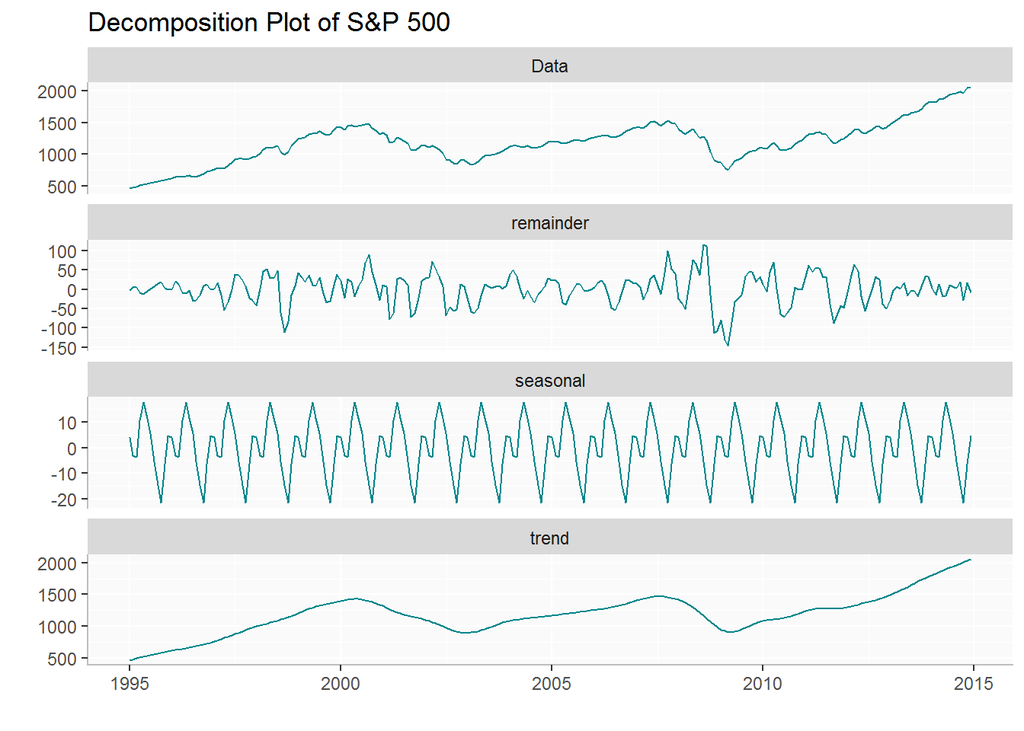

```r
#Beyond understanding the trend of our time-series, we want to further understand the anatomy of our data. For this reason we break-down our time-series into its seasonal component, trend, and residuals.

plot_decomp(sp500_training, 'S&P 500')
```

```r
#The trend line already shows us what we know and we can see that there might be some seasonality in our time series object.
```

#Model Estimation

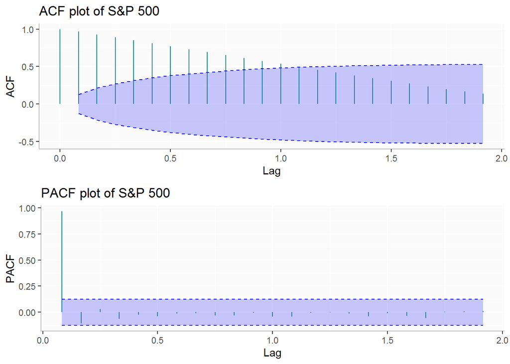

```r
#Diagnosing the ACF and PACF Plots of our Time-Series Object

#ACF stands for "autocorrelation function" and PACF stands for "partial autocorrelation function". The ACF and PACF diagnosis is employed over a time-series to determine the order for which we are going to create our model using ARIMA modeling. Loosely speaking, a time-series is stationary when its mean, variance, and autocorrelation remain constant over time.

#These functions help us understand the correlation component of different data points at different time lags. Lag refers to the time difference between one observation and a previous observation in a dataset. Let's examine our plots!

# DIAGNOSING ACF AND PACF PLOTS
plot_acf_pacf(sp500_training, 'S&P 500')
```

```r
#Transforming our data to adjust for non-stationary

#From visual inspection of the time series object and the previously mentioned statistical tests used for exploratory analysis, we decided it is appropriate to difference our time series object to account for the non-stationarity and see how that fares!

#A way to make a time-series stationary is to find the difference across its consecutive values. This helps stabilize the mean, thereby making the time-series object stationary.

#For this we use the diff() method.

tsDiff <- diff(sp500_training)
```

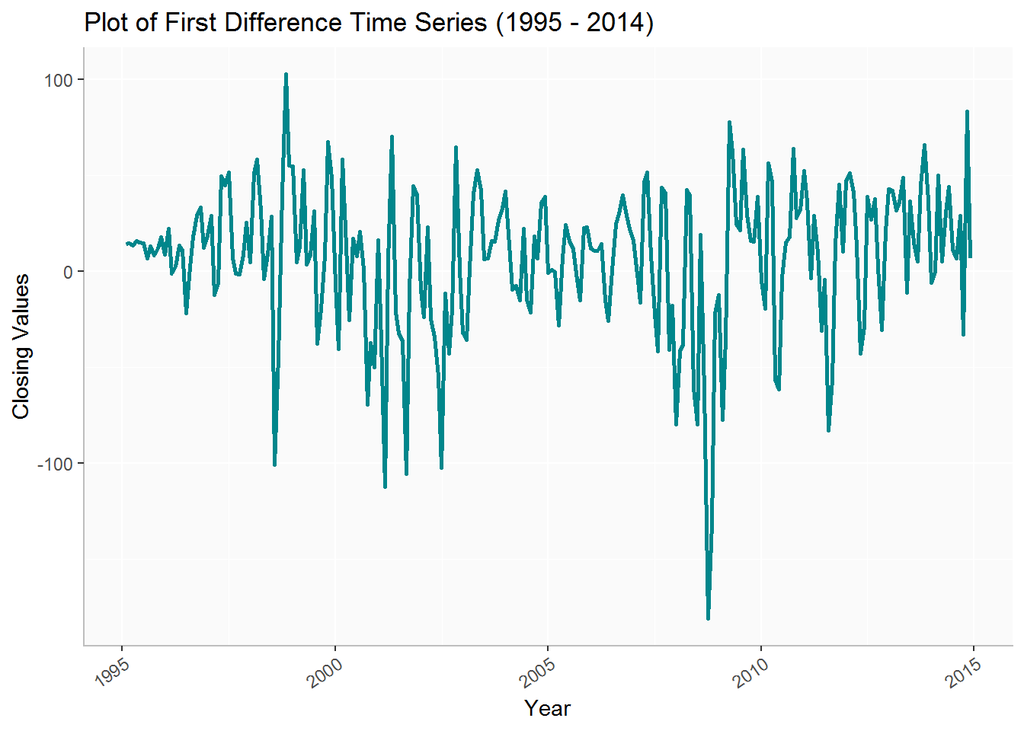

```r
#Next we plot our transformed time-series:

plot_time_series(tsDiff, 'First Difference')
```

```r
#This plot suggests that our working data is stationary. We want to confirm this running the same tests, and looking at the ACF and PACF diagnostics over the differenced data to find our if we can proceed to estimating a model.
```

#Testing for Stationarity

```r
#We apply the same tests to our differenced time series object.

Box.test(tsDiff, lag = 20, type = 'Ljung-Box')
```

```
##
##  Box-Ljung test
##
## data:  tsDiff
## X-squared = 58.845, df = 20, p-value = 1.073e-05
```

```r
#Now let's use the ADF Test

adf.test(tsDiff)
```

```
##
##  Augmented Dickey-Fuller Test
##
## data:  tsDiff
## Dickey-Fuller = -4.7775, Lag order = 6, p-value = 0.01
## alternative hypothesis: stationary
```

```r
#we can see that the result yields a small p-value which makes us reject the null suggestion stationarity.
```

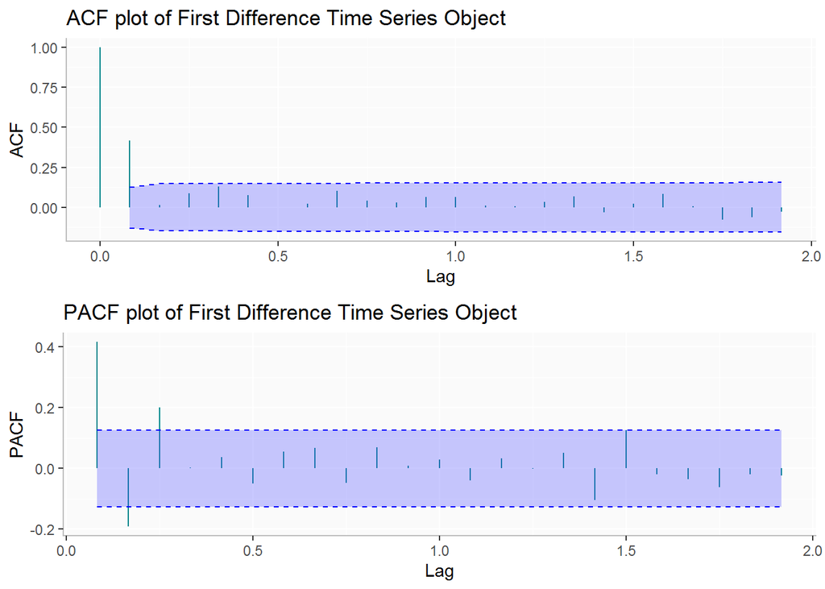

```r
#Diagnosing the acf and pacf of our transformed time-series object

#The plot below helps us confirm that we have stationarity and also helps us deduce which model we will use. It is important to keep in mind that we have a difference parameter equal to one (i.e. d = 1) because of the previous transformation we carried out.

plot_acf_pacf(tsDiff, 'First Difference Time Series Object')
```

```r
#From the above plots we deduce that an MA(1) model (where MA stands for moving average) best fits our data because the ACF cuts off at one significant lag and the PACF shows geometric decay.
#Recall that we are examining the differenced time-series so we have to use the combined model ARIMA (Autoregressive integrated moving average), thus our model so far is ARIMA(0, 1, 1).
```

#Build Model

```r
#Our findings in the exploratory analysis phase suggest that model ARIMA(0, 1, 1) might be best fit. Fortunately, there is a function in R that we can use to test our findings.

#The auto.arima() method, found within the forecast package, yields the best model for a time-series based on Akaike-Information-Criterion (AIC). The AIC is a measurement of quality used across various models to find the best fit. After running our original and differenced data sets through the auto.arima() method we confirmed that the ARIMA(0, 1, 1) is our best fit model.

#We use the Arima() method to fit our model and include our training data set sp500_training as the first argument.

fit <- Arima(sp500_training, order = c(0,1,1),
             include.drift = TRUE)
summary(fit)
```

[output not shown]

```
## Series: sp500_training
## ARIMA(0,1,1) with drift
##
## Coefficients:
##          ma1   drift
##       0.5666  6.4975
## s.e.  0.0551  3.4326
##
## sigma^2 estimated as 1161:  log likelihood=-1181.58
## AIC=2369.17   AICc=2369.27   BIC=2379.59
##
## Training set error measures:
##                       ME     RMSE      MAE         MPE     MAPE      MASE
## Training set -0.00911296 33.85289 24.84955 -0.00840343 2.141218 0.1310854
##                     ACF1
## Training set -0.01137429
```